# PEC 1 Análisis metabolómico de pacientes caquéxicos

Irene de Diego Tamayo

2024-11-03

# Introducción

La caquexia es un síndrome que se caracteriza por la pérdida continua de peso, incluyendo masa muscular esquelética, grasa y hueso, que conyeva serias deficiencias nutricionales, pérdida de apetito y extrema debilidad. Esta condición se desarrolla con frecuencia en personas con enfermedades crónicas como el cáncer, infecciones, cardiovasculares y otras enfermedades graves.

En la caquexia, la pérdida de masa muscular se produce debido a un constante estado catabólico, pérdida del apetito y aumento de la inflamación. Es muy común que, ante la falta de nutrientes esenciales, el cuerpo entre en estado de cetosis.

En el presente trabajo se realiza una exploración superficial de los datos obtenidos del dataset *human.cachexia*, un estudio metabolómico que compara pacientes caquéxicos con un grupo control. El análisis exploratorio constará de un análisis superficial de la distribución de los datos, seguido por un análisis de componentes principales y un análisis de expresión diferencial.

# Objetivos

- Realizar una primera exploración de los datos
- Comprobar si existen diferencias en los metabolitos de pacientes caquéxicos vs grupo control.

# Materiales y métodos

El dataset se descargó del repositorio de github: [nutrimetabolomics](https://github.com/nutrimetabolomics/metaboData/tree/main/Datasets) con el nombre *2024-Cachexia.*

El análisis exploratorio se realizó con R-studio. Los paquetes utilizados se detallan a continuación:

- Bioconductor (Biobase)
- SummarizedExperiment
- Tidyverse
- Pheatmap
- Ggplot2
- Limma

El documento de R-Marckdown contiene las instrucciones necesarias para instalar estos paquetes de forma automática.

Todos los archivos necesarios para realizar el presente trabajo pueden encontrarse en el repositorio de github: DE_DIEGO-Tamayo-Irene-PEC1.

# Exploración de los datos e interpretación

Cargamos los paquetes necesarios:

```r
library(Biobase)
library(SummarizedExperiment)
library(tidyverse)
library(pheatmap)
library(ggplot2)
library(limma)
```

## 1. Cargado de los datos y creación del SummarizedExperiment

```r
cac <- read.csv("human_cachexia.csv")
```

**Primera exploración de los datos:**

```r
str(cac)
```

```
## 'data.frame':    77 obs. of  65 variables:
##  $ Patient.ID                 : chr  "PIF_178" "PIF_087" "PIF_090" "NETL_005_V1" ...
##  $ Muscle.loss                : chr  "cachexic" "cachexic" "cachexic" "cachexic" ...
##  $ X1.6.Anhydro.beta.D.glucose: num  40.9 62.2 270.4 154.5 22.2 ...
##  $ X1.Methylnicotinamide      : num  65.4 340.4 64.7 53 73.7 ...
##  $ X2.Aminobutyrate           : num  18.7 24.3 12.2 172.4 15.6 ...
##  $ X2.Hydroxyisobutyrate      : num  26.1 41.7 65.4 74.4 83.9 ...
##  $ X2.Oxoglutarate            : num  71.5 67.4 23.8 1199.9 33.1 ...
##  $ X3.Aminoisobutyrate        : num  1480.3 116.8 14.3 555.6 29.7 ...
##  $ X3.Hydroxybutyrate         : num  56.83 43.82 5.64 175.91 76.71 ...
##  $ X3.Hydroxyisovalerate      : num  10.1 79.8 23.3 25 69.4 ...
##  $ X3.Indoxylsulfate          : num  567 369 665 412 166 ...
##  $ X4.Hydroxyphenylacetate    : num  120.3 432.7 292.9 214.9 97.5 ...
##  $ Acetate                    : num  126.5 212.7 314.2 37.3 407.5 ...
##  $ Acetone                    : num  9.49 11.82 4.44 206.44 44.26 ...
```

[output cut: 51 more lines]

El archivo contiene 77 observaciones y 65 variables, de las cuales 2 corresponden a metadatos:

- *Patient.ID*: número de identificación del paciente
- *Muscle.Loss*: variable que segrega a los pacientes en dos grupos: “cachexic” y “control”

La variable *Muscle.Loss* debería ser de tipo factor pero está mal caracterizada como tipo caracter, así que la transformamos:

```r
cac$Muscle.loss <- as.factor(cac$Muscle.loss)
```

**Creación del objeto `SummarizedExperiment`**

Para crear un objeto `SummarizedExperiment`, primero debemos extraer los datos de expresión en una matriz (*assay*) y los metadatos en otra (*colData*).

Comenzamos por la matriz de datos (excluyendo los metadatos *“Patient.ID”* y *“Muscle.Loss”*):

```r
datos <- as.matrix(cac[, -c(1, 2)])
rownames(datos) <- cac$Patient.ID
datos <- t(datos) # transponemos la matriz
```

A continuación, creamos la matriz *colData* con los metadatos:

```r
col_data <- DataFrame(Patient_ID = cac$Patient.ID,
                      Muscle_loss = cac$Muscle.loss)
rownames(col_data) <- cac$Patient.ID
```

Finalmente, creamos el objeto `SummarizedExperiment` usando `col_data` y la matriz `datos`

```r
# Creamos el objeto SummarizedExperiment
se <- SummarizedExperiment(
  assays = list(metabolites = datos),
  colData = col_data
  )

se
```

```
## class: SummarizedExperiment
## dim: 63 77
## metadata(0):
## assays(1): metabolites
## rownames(63): X1.6.Anhydro.beta.D.glucose X1.Methylnicotinamide ...
##   pi.Methylhistidine tau.Methylhistidine
## rowData names(0):
## colnames(77): PIF_178 PIF_087 ... NETL_003_V1 NETL_003_V2
## colData names(2): Patient_ID Muscle_loss
```

## 2. Análisis exploratorio básico

Antes de nada, comprobamos si existen valores faltantes (*missing values*):

```r
sum(is.na(assay(se)))
```

```
## [1] 0
```

No hay ningún valor faltante, así que procedemos con el análisis exploratorio. Primero, observamos la distribución de muestras en cada grupo:

```r
table(colData(se)$Muscle_loss)
```

```
##
## cachexic  control
##       47       30
```

**Cálculo de estadísticos básicos:**

```r
met_stats <- data.frame(
  Mean = rowMeans(datos),
  SD = apply(datos, 1, sd),
  Median = apply(datos, 1, median),
  IQR = apply(datos, 1, IQR)
)

met_stats
```

```
##                                    Mean          SD  Median     IQR
## X1.6.Anhydro.beta.D.glucose  105.630390  130.025595   45.60  112.38
## X1.Methylnicotinamide         71.573636  133.192811   36.60   57.90
## X2.Aminobutyrate              18.159740   27.614526   10.49   14.23
## X2.Hydroxyisobutyrate         37.250649   23.956807   32.46   38.80
## X2.Oxoglutarate              145.087143  342.522174   55.15   70.34
## X3.Aminoisobutyrate           76.756364  191.014237   22.65   44.56
## X3.Hydroxybutyrate            21.717013   26.198904   11.70   23.97
## X3.Hydroxyisovalerate         21.647792   24.946091   12.55   25.01
## X3.Indoxylsulfate            218.879221  196.868730  144.03  251.35
## X4.Hydroxyphenylacetate      112.021039  120.812569   70.11  103.79
## Acetate                       66.141429   79.212562   39.65   70.21
## Acetone                       11.427013   23.460432    7.10    5.54
## Adipate                       24.756364   50.426898   10.18   13.00
## Alanine                      273.562338  256.985016  194.42  321.15
## Asparagine                    62.283636   53.951507   42.10   68.63
## Betaine                       90.324675   82.720360   64.72   98.95
## Carnitine                     52.085065   73.944144   23.81   46.51
## Citrate                     2235.345974 2166.567733 1790.05 2283.34
## Creatine                     126.831948  273.216370   44.26  100.28
## Creatinine                  8733.971818 6477.617261 7631.20 8834.39
## Dimethylamine                358.166104  307.822835  304.90  312.27
## Ethanolamine                 276.260390  251.780477  204.38  320.99
## Formate                      147.402987  187.181079   95.58  113.82
## Fucose                        88.668831   80.658497   61.56   94.60
## Fumarate                       8.440130   14.467064    4.10    5.62
## Glucose                      559.844545 1386.940378  210.61  326.84
## Glutamine                    306.871558  290.971907  225.88  332.56
## Glycine                      880.717403  949.692892  528.48  834.20
## Glycolate                    187.989351  180.423391  130.32  216.83
## Guanidoacetate                86.370519   83.095325   64.72   75.07
## Hippurate                   2286.837662 2870.317404 1224.15 2429.18
## Histidine                    292.637532  312.756874  174.16  353.20
## Hypoxanthine                  61.097662   57.529792   40.04   63.23
## Isoleucine                     8.709091    6.935195    7.17    7.35
## Lactate                      158.456494  420.401343   81.45  104.25
## Leucine                       24.363636   21.515644   19.11   22.07
## Lysine                       108.794156  126.659344   69.41   91.24
## Methylamine                   17.376234   13.915350   14.73   18.79
## Methylguanidine               15.324545   19.847857    7.85   15.04
```

[output cut: 9 more lines]

```
## Tartrate                      40.004026  103.482428   12.94   18.90
## Taurine                      525.123506  673.848756  249.64  565.66
## Threonine                     95.357403   87.097645   64.07  105.18
## Trigonelline                 270.436104  398.086055  114.43  286.84
## Trimethylamine.N.oxide       652.156883  910.149632  383.75  559.19
## Tryptophan                    66.243117   56.333318   46.99   75.21
## Tyrosine                      81.757273   83.248486   60.34   89.73
## Uracil                        35.557662   35.002894   27.39   32.32
## Valine                        35.667013   29.697365   33.12   38.22
## Xylose                       100.933377  250.216325   50.40   59.16
## cis.Aconitate                204.219740  278.141989  129.02  218.45
## myo.Inositol                 135.397532  170.266474   78.26  137.07
## trans.Aconitate               40.630390   39.566754   26.84   44.97
## pi.Methylhistidine           370.288312  530.689300  162.39  320.25
## tau.Methylhistidine           89.686883   77.239064   68.72  102.93
```

Creamos un violin plot para visualizar la distribución de los datos de expresión:

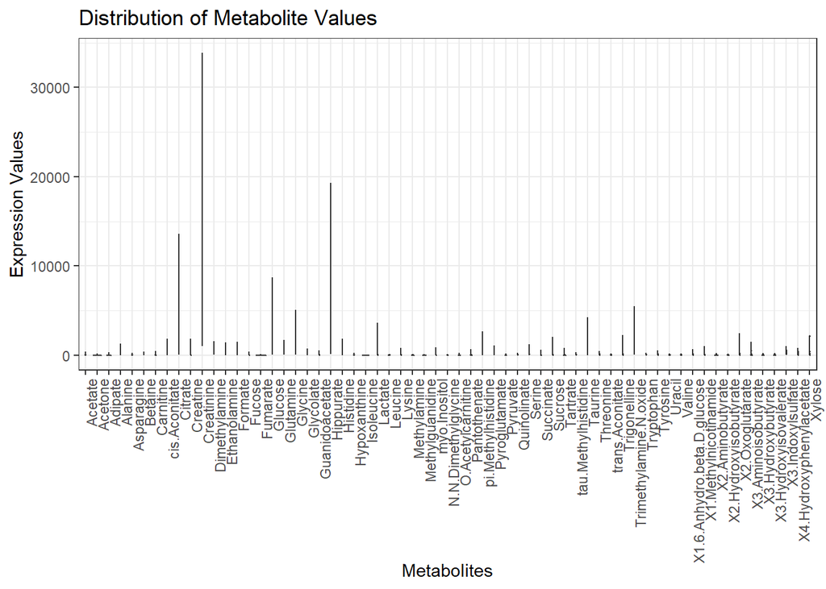

```r
metabol <- as.data.frame(datos) %>%
  rownames_to_column("Metabolite") %>%
  pivot_longer(-Metabolite, names_to = "Sample", values_to = "Value")

ggplot(metabol, aes(x = Metabolite, y = Value)) +
  geom_violin() +
  theme_bw() +
  theme(axis.text.x = element_text(angle = 90, hjust = 1)) +
  labs(title = "Distribution of Metabolite Values",
       x = "Metabolites",
       y = "Expression Values")
```

**Cálculo y visualización de correlaciones:**

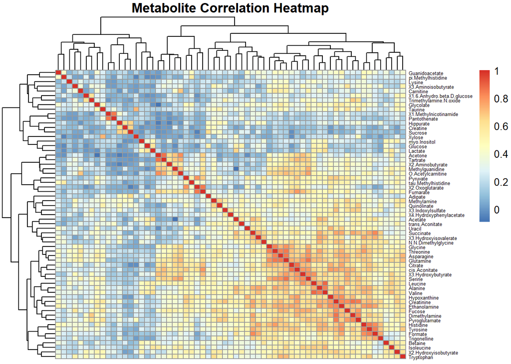

```r
cor_matrix <- cor(t(assay(se)))
pheatmap(cor_matrix,
         show_rownames = TRUE,
         show_colnames = FALSE,
         main = "Metabolite Correlation Heatmap",
         fontsize_row = 5)
```

En este gráfico vemos si existe correlación entre la expresión de ciertos metabolitos. El color rojo/naranja indica una alta correlación, por lo que son metabolitos que suelen co-expresarse.

Para tener una idea más clara de cuáles son los metabolitos con una mayor correlación, procedemos a generar una lista de las correlaciones más fuertes:

```r
# Convertimos la matriz en un data frame
cor_df <- as.data.frame(as.table(cor_matrix))

# Filtramos las correlaciones de cada variable consigo misma (diagonal)
cor_df <- cor_df[cor_df$Var1 != cor_df$Var2, ]

# Ordenamos las correlaciones por nivel de magnitud
cor_df <- cor_df[order(-abs(cor_df$Freq)), ]

# Filtramos los duplicados eliminando todas las líneas pares
top_cor <- cor_df[seq(1, nrow(cor_df), by = 2), ]

# Seleccionamos las 10 correlaciones más fuertes
head(top_cor, 10)
```

```
##               Var1                  Var2      Freq
## 2262        Valine               Leucine 0.8804148
## 1684        Serine             Glutamine 0.8674403
## 1130 cis.Aconitate               Citrate 0.8628231
## 1218 Dimethylamine            Creatinine 0.8623471
## 742       Tartrate               Acetone 0.8588489
## 277       Fumarate       X2.Oxoglutarate 0.8573558
## 2008      Tyrosine             Histidine 0.8572686
## 909      Glutamine            Asparagine 0.8556964
## 105   Pantothenate X1.Methylnicotinamide 0.8494645
## 1689     Threonine             Glutamine 0.8477669
```

## 3. Análisis de componentes principales

En este apartado procedemos a reducir la dimensionalidad de nuestros datos usando un análisis de componentes principales.

```r
pca_result <- prcomp(t(assay(se)), scale. = TRUE)
```

Queremos ver qué componentes explican la mayor parte de la varianza en nuestros datos. Para ello, extraemos primero las varianzas explicadas por cada componente:

```r
loads <- round(pca_result$sdev^2 / sum(pca_result$sdev^2) * 100, 1)
```

Y calculamos la varianza acumulada:

```r
cumulative_var <- cumsum(loads)
cumulative_var
```

```
##  [1] 40.4 48.6 53.9 58.7 63.1 67.2 70.6 73.6 76.1 78.4 80.5 82.3 84.0 85.6 87.1
## [16] 88.4 89.6 90.7 91.7 92.6 93.4 94.2 94.9 95.5 96.0 96.5 96.9 97.3 97.6 97.9
## [31] 98.2 98.4 98.6 98.8 99.0 99.1 99.2 99.3 99.4 99.5 99.6 99.7 99.8 99.8 99.8
## [46] 99.8 99.8 99.8 99.8 99.8 99.8 99.8 99.8 99.8 99.8 99.8 99.8 99.8 99.8 99.8
## [61] 99.8 99.8 99.8
```

Vemos que los 11 primeros PCs explican el 80.5% de la varianza.

Para visualizar estas relaciones, podemos realizar un plot con los primeros dos PCs, los cuales explican el 48.6% de la varianza total.

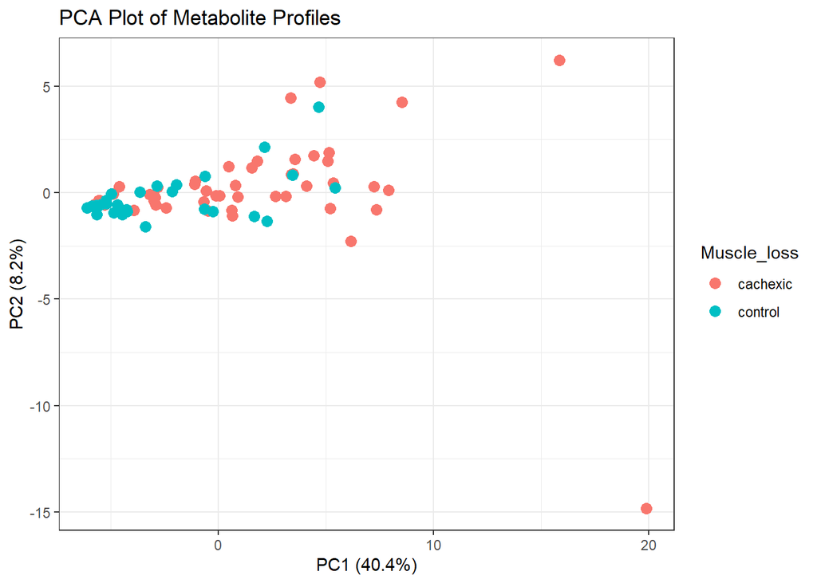

```r
# seleccionamos sólo los dos primeros componentes principales
pca_data <- as.data.frame(pca_result$x[,1:2])
# Extraemos los grupos cachexic y control
pca_data$Muscle_loss <- colData(se)$Muscle_loss

# Construimos el plot:
ggplot(pca_data, aes(x = PC1, y = PC2, color = Muscle_loss)) +
  geom_point(size = 3) +
  theme_bw() +
  labs(title = "PCA Plot of Metabolite Profiles",
       x = paste0("PC1 (", round(summary(pca_result)$importance[2,1] * 100, 1), "%)"),
       y = paste0("PC2 (", round(summary(pca_result)$importance[2,2] * 100, 1), "%)"))
```

Aunque hay solapamiento, vemos que el PC1 es capaz de separar a ambos grupos: los individuos caquéxicos tienden a tener valores más altos en PC1 que los del grupo control.

Finalmente, inspeccionamos qué metabolitos están contribuyendo más fuertemente en el PC1.

```r
PC1_loads <- pca_result$rotation[,1]
head(sort(PC1_loads, decreasing = TRUE))
```

```
##   Creatinine    Glutamine Ethanolamine   Asparagine    Threonine       Valine
##    0.1754974    0.1708957    0.1704181    0.1691602    0.1684597    0.1679131
```

El resultado es interesante, ya que estos metabolitos están relacionados con el daño muscular, inflamación y síntesis proteica.

- La creatinina es un producto de desecho de células musculares que se eleva en situaciones de daño muscular y/o filtrado deficiente de los riñones, lo cual suele ser típico en pacientes cachexicos.
- La glutamina es un aminoácido implicado en la síntesis de nucleótidos y proteínas, y juega un papel crítico en el sistema inmunitario. Niveles bajos de este metabolito podrían reflejar un mayor uso en procesos inflamatorios (la caquexia está asociada a inflamación sistémica).
- La etanolamina sirve como precursor de fosfolípidos. Alteraciones en sus niveles pueden indicar cambios en la composición de membranas celulares y estrés celular.
- La asparagina, treonina y valina son aminoácidos que juegan un papel importante en el transporte de nitrógeno y la síntesis proteica. Debido a que la caquexia aumenta la tasa de destrucción de músculo, es esperable encontrar niveles alterados de ciertos aminoácidos.

## 4. Análisis de expresión diferencial

Tras la exploración superficial de los datos, procedemos a realizar un análisis más sofisticado que nos muestre diferencias entre los grpos cachexic y control. Para ello, usaremos el análisis de expresión diferencial.

```r
# Creamos la matriz de diseño
design <- model.matrix(~ Muscle_loss, data = colData(se))

# Ajustamos el modelo lineal a los datos de expresión
fit <- lmFit(assay(se), design)

# Aplicamos la moderación Bayesiana para ajustar los p-valores
fit <- eBayes(fit)

# Obtención de los resultados (cachexic vs. control)
res <- topTable(fit, coef = "Muscle_losscontrol", number = Inf)

# Filtramos los resultados más significativos (e.g., adjusted p-value < 0.01)
significant_res <- res[res$adj.P.Val < 0.01, ]
significant_res
```

```
##                           logFC    AveExpr         t      P.Value   adj.P.Val
## Quinolinate           -44.42323   66.43948 -4.059026 0.0001187889 0.004261236
## Valine                -25.44989   35.66701 -3.966611 0.0001640210 0.004261236
## N.N.Dimethylglycine   -20.89312   26.34961 -3.904997 0.0002029160 0.004261236
## Leucine               -17.70504   24.36364 -3.721952 0.0003775515 0.004313003
## Dimethylamine        -244.89730  358.16610 -3.692244 0.0004169006 0.004313003
## Pyroglutamate        -151.03434  211.44779 -3.666129 0.0004546884 0.004313003
## Creatinine          -5102.96555 8733.97182 -3.650258 0.0004792226 0.004313003
## Glutamine            -216.98309  306.87156 -3.423593 0.0009999880 0.007791122
## Alanine              -190.00706  273.56234 -3.389840 0.0011130175 0.007791122
## X3.Hydroxybutyrate    -19.36197   21.71701 -3.317829 0.0013956410 0.008792538
##                             B
## Quinolinate         -3.924607
## Valine              -3.951915
## N.N.Dimethylglycine -3.970002
## Leucine             -4.023109
## Dimethylamine       -4.031633
## Pyroglutamate       -4.039101
## Creatinine          -4.043630
## Glutamine           -4.107328
## Alanine             -4.116647
## X3.Hydroxybutyrate  -4.136374
```

A continuación, observamos los datos en un volcano plot

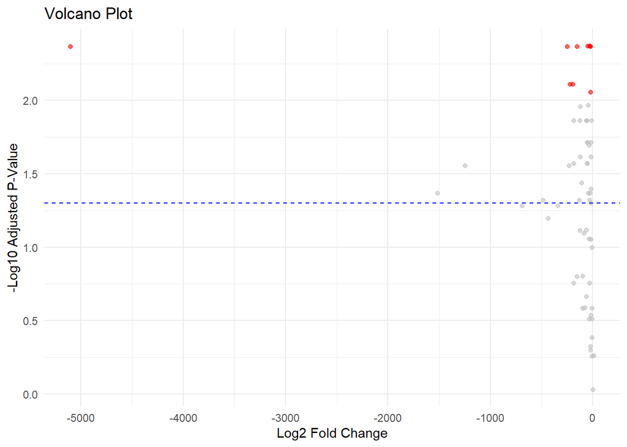

```r
ggplot(res, aes(x = logFC, y = -log10(adj.P.Val))) +
  geom_point(aes(color = adj.P.Val < 0.01), alpha = 0.6) +
  scale_color_manual(values = c("grey", "red")) +
  labs(title = "Volcano Plot", x = "Log2 Fold Change", y = "-Log10 Adjusted P-Value") +
  theme_minimal() +
  theme(legend.position = "none") +
  geom_hline(yintercept = -log10(0.05), linetype = "dashed", color = "blue")
```

En rojo vemos los metabolitos estadísticamente significativos al 99% de confianza.

# Conclusiones

Nuestro análisis superficial de los datos reveló las diferencias en los niveles de ciertos metabolitos en pacientes caquéxicos vs control. Los metabolitos que parecen contribuir en mayor medida al fenotipo caquexia fueron los siguientes:

- Creatinine
- Glutamine
- Ethanolamine
- Asparagine
- Threonine
- Valine
- Quinolinate
- N.N.Dimethylglycine
- Dimethylamine
- Pyroglutamate
- X3.Hydroxybutyrate

Los niveles más altos de estos metabolitos en pacientes caquésicos sugieren que existen alteraciones metabólicas debido a la pérdida de peso, en concreto de masa muscular, estrés metabólico e inflamación.